# Formula Interface for ggplot2

Daniel Kaplan and Randall Pruim

June 17, 2017

# Formula-driven graphics

There are several excellent graphics packages provided for R. The `ggformula` package currently builds on one of them, `ggplot2`, but provides a very different user interface for creating plots. The interface is based on formulas (much like the `lattice` interface) and the use of the chaining operator (`%>%`) to build more complex graphics from simpler components.

Experts, of course, will want to use the underlying `ggplot2` package directly in order to maximize expressiveness and minimize the “bureaucracy” induced by intervening layers of software. The `ggformula` graphics are suited for

- beginners, who don’t require the full range of `ggplot2` capabilities, but want to get started quickly,
- those familiar with `lattice` graphics, but wanting to be able to easily create multilayered plots,
- those who prefer a formula interface, perhaps because it is familiar from use with function like `lm()` or from use of the `mosaic` package for numerical summaries.

## The basic formula template

The basic template for creating a plot with `ggformula` is

```r
gf_plottype(formula, data = mydata)
```

where

- `plottype` describes the type of plot (layer) desired (points, lines, a histogram, etc., etc.),
- `mydata` is a data frame containing the variables used in the plot, and
- `formula` describes how/where those variables are used.

For example, in a bivariate plot, `formula` will take the form `y ~ x`, where `y` is the name of a variable to be plotted on the y-axis and `x` is the name of a variable to be plotted on the x-axis. (It is also possible to use expressions that can be evaluated using variables in the data frame as well.)

Here is a simple example:

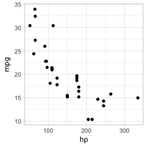

```r
library(ggformula)
gf_point(mpg ~ hp, data = mtcars)
```

## Selecting the glyph type

The “kind of graphic” is specified by the name of the graphics function. All of the `ggformula` data graphics functions have names starting with `gf_`, which is intended to remind the user that they are formula-based interfaces to `ggplot2`: `g` for `ggplot2` and `f` for “formula.” Commonly used functions include

- `gf_point()` for scatter plots
- `gf_line()` for line plots (connecting dots in a scatter plot)
- `gf_density()` or `gf_dens()` or `gf_histogram()` or `gf_freqpoly()` to display distributions of a quantitative variable
- `gf_boxplot()` or `gf_violin()` for comparing distributions side-by-side
- `gf_counts()` for bar-graph style depictions of counts.
- `gf_bar()` for more general bar-graph style graphics

The function names generally match the corresponding function name from `ggplot2`, although `gf_counts()` is a simplified special case, and `gf_dens()` is an alternative to `gf_density()` that displays the density plot slightly differently than the default in `ggplot2`.

Each of the `gf_` functions can create the coordinate axes and fill it in one operation. (In `ggplot2` nomenclature, `gf_` functions create a frame and add a geom layer, all in one operation.) This is what happens for the first `gf_` function in a chain. For subsequent `gf_` functions, new layers are added, each one “on top of” the previous layers.

## Attributes

Each of the marks in the plot is a *glyph*. Every glyph has graphical *attributes* (called aesthetics in `ggplot2`) that tell where and how to draw the glyph. In the above plot, the obvious attributes are x- and y-position:  
We’ve told R to put `mpg` along the y-axis and `hp` along the x-asis, as is clear from the plot. But each point also has other attributes, including color, shape, size, stroke, fill, and alpha (transparency). We didn’t specify those in our example, so `gf_point()` uses some default values for those – in this case smallish black filled-in circles.

### Specifying attributes

In the `gf_` functions, you specify the non-position graphical attributes using an extension of the basic formula. Attributes can be **set** to a constant value (e.g, set the color to “blue”; set the size to 2) or they can be **mapped** to a variable in the data or some expression involving the variables (e.g., map the color to `sex`, so sex determines the color groupings)

Attributes are set or mapped using additional arguments.

- adding an argument of the form `attribute = value` **sets** `attribute` to `value`.
- adding an argument of the form `attribute = ~ expression` **maps** `attribute` to `expression`

where `attribute` is one of `color`, `shape`, etc., `value` is a constant (e.g. `"red"` or `0.5`, as appropriate), and `expression` may be some more general expression that can be computed using the variables in `data` (although often is is better to create a new variable in the data and to use that variable instead of an on-the-fly calculation within the plot).

The following plot, for instance,

- We use `cyl` to determine the color and `carb` to determine the size of each dot. Color and size are **mapped** to `cyl` and `carb`. A legend is provided to show us how the mapping is being done. (Later, we can use scales to control precisely how the mapping is done – which colors and sizes are used to represent which values of `cyl` and `carb`.)
- We also **set** the transparency to 50%. The gives the same value of `alpha` to all glyphs in this layer.

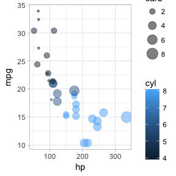

```r
gf_point(mpg ~ hp, color = ~ cyl, size = ~carb, alpha = 0.50, data = mtcars)
```

Here is the same plot where mapping and setting are indicated explicitly.

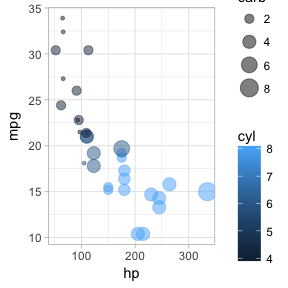

```r
# set alpha using a function argument instead of in the formula
gf_point(mpg ~ hp, color = ~cyl, size = ~carb, alpha = 0.50, data = mtcars)
```

### On-the-fly calculations

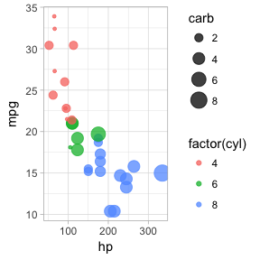

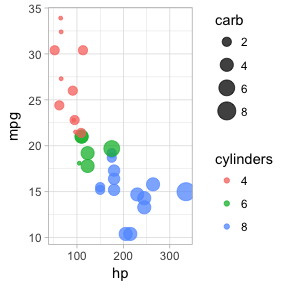

```r
gf_point(mpg ~ hp,  color = ~factor(cyl), size = ~carb, alpha = 0.75, data = mtcars)
gf_point(mpg ~ hp,  color = ~cylinders, size = ~carb, alpha = 0.75,
         data = mtcars %>% mutate(cylinders = factor(cyl)))
```

## “One-variable” plots

For some plots, we only have to specify the x-position because the y-position is calculated from the x-values. Histograms, densityplots, and frequency polygons are examples. To illustrate, we’ll use density plots, but the same ideas apply to `gf_histogram()`, and `gf_freqpolygon()` as well. *Note that in the one-variable density graphics, the variable whose density is to be calculated goes to the right of the tilde, in the position reserved for the x-axis variable.*

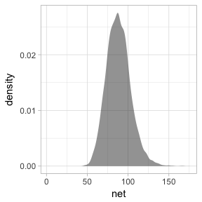

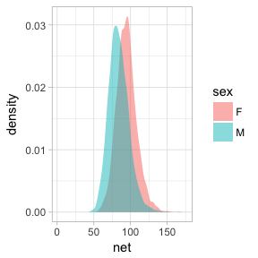

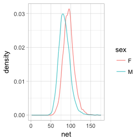

```r
data(Runners, package = "statisticalModeling")
Runners <- Runners %>% filter( ! is.na(net))
gf_density( ~ net, data = Runners)
gf_density( ~ net,  fill = ~sex,  alpha = 0.5, data = Runners)
# gf_dens() is similar, but there is no line at bottom/sides, and it is not "fillable"
gf_dens( ~ net, color = ~sex, alpha = 0.7, data = Runners)
```

Several of the plotting functions include additional arguments that do not modify attributes of individual glyphs but control some other aspect of the plot. In this case, `adjust` can be used to increase or decrease the amount of smoothing.

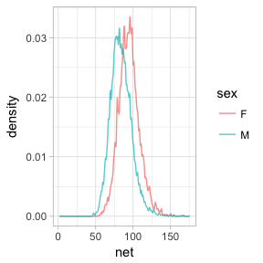

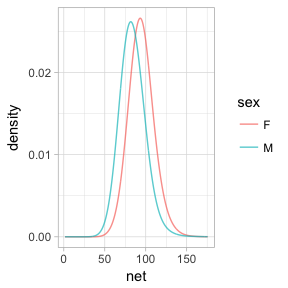

```r
# less smoothing
gf_dens( ~ net, color = ~sex, alpha = 0.7, data = Runners, adjust = 0.25)
# more smoothing
gf_dens( ~ net, color = ~sex, alpha = 0.7, data = Runners, adjust = 4)
```

## Position

When the `fill` or `color` or `group` aesthetics are mapped to a variable, the default behavior is to lay the group-wise densities on top of one another. Other behavior is also available by using `position` in the formula. Using the value `"stack"` causes the densities to be laid one on top of another, so that the overall height of the stack is the density across all groups. The value `"fill"` produces a conditional probability graphic.

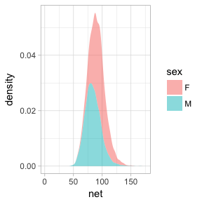

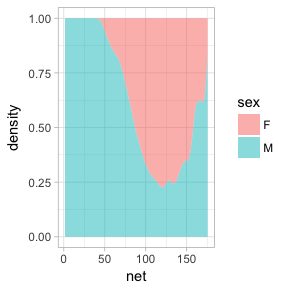

```r
gf_density( ~ net, fill = ~sex, color = NA, position = "stack", data = Runners)
gf_density( ~ net, fill = ~sex, color = NA, position = "fill", data = Runners, adjust = 2)
```

Similar commands can be constructed with `gf_histogram()` and `gf_freqpoly()`, but note that `color`, not `fill`, is the active attribute for frequency polygons. It’s also rarely good to overlay histograms on top of one another – better to use a density plot or a frequency polygon for that application.

## More 2-variable plots

### Using jitter and transparency to handle overlapping cases

Sometimes you have so many points in a scatter plot that they obscure one another. The `ggplot2` system provides two easy ways to deal with this: translucency and jittering.

Use `alpha = 0.5` to make the points semi-translucent. If there are many points overlapping at one point, a much smaller value of alpha, say `alpha = 0.01`. We’ve already seen this above.

Using `gf_jitter()` in place of `gf_point()` will move the plotted points to reduce overlap. Jitter and transparency can be used together as well.

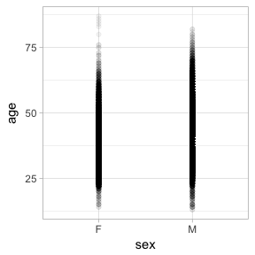

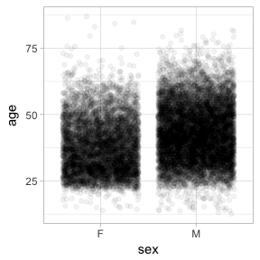

```r
gf_point(age ~ sex, alpha = 0.05, data = Runners)
gf_jitter(age ~ sex, alpha = 0.05, data = Runners)
```

### Box and Whisker plots

Box and whisker plots show the distribution of a quantitative variable as a function of a categorical variable. The formula used in `gf_boxplot()` should have the quantitative variable to the left of the tilde. (To make horizontal boxplots using `ggplot2` you have to make vertical boxplots and then flip the coordinates with `coord_flip()`.)

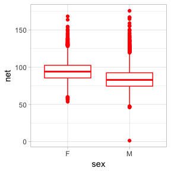

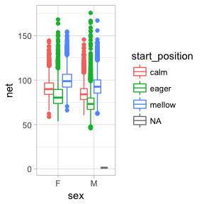

```r
gf_boxplot(net ~ sex, color = "red", data = Runners)
gf_boxplot(net ~ sex, color = ~start_position, data = Runners)
```

This plot may surprise you.

```
## Warning: Continuous x aesthetic -- did you forget aes(group=...)?
```

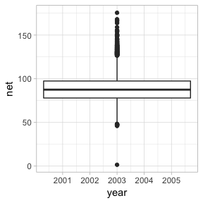

```r
gf_boxplot(net ~ year, data = Runners)
```

This plot is placing a single box and whisker plot at the mean value of `year`. The warning message suggests that we need to tell R how to form the groups when using a quantitative variable for `x`. It suggests using the `group` aesthetic, and sometimes, this is just what we want.

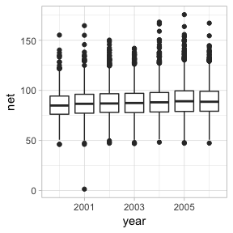

```r
gf_boxplot(net ~ year, group = ~ year, data = Runners)
```

But often, is is better to convert a discrete quantitative variable used for grouping into a categorical variable (a factor or character vector). This can be done in several ways:

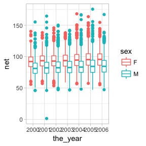

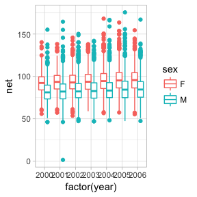

```r
# add a new variable to the data
Runners$the_year <- as.character(Runners$year)               # in base R
Runners <- Runners %>% mutate(the_year = as.character(year)) # in dplyr
gf_boxplot(net ~ the_year, color = ~sex, data = Runners)
# or do it on the fly
gf_boxplot(net ~ factor(year), color = ~sex, data = Runners)
```

### 2-dimensional density plots

Two-dimensional plots of density also have both a left and right component to the formula.

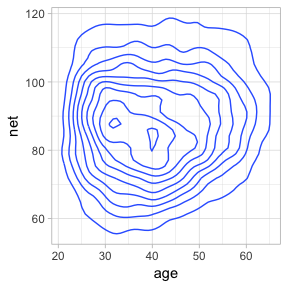

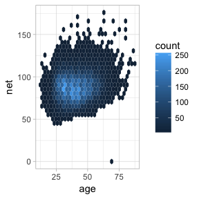

```r
gf_density_2d(net ~ age, data = Runners)
gf_hex(net ~ age, data = Runners)
```

### Paths and lines

The `ggplot2` system offers two ways to connect points. `gf_line()` ignores the order of the points in the data, and draws the line going from left to right. `gf_path()` goes from point to point according to the order in the data. Both forms can use a `color` or `group` aesthetic as a flag to draw groupwise lines.

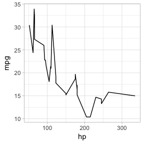

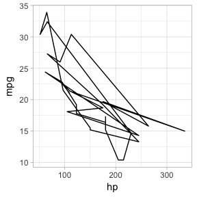

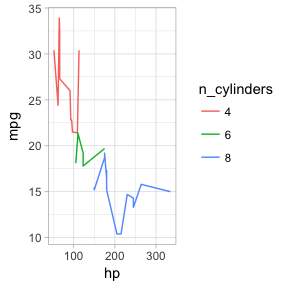

```r
# create a categorical variable
mtcars <- mtcars %>% mutate(n_cylinders = as.character(cyl))
gf_line(mpg ~ hp, data = mtcars)
gf_path(mpg ~ hp, data = mtcars)
gf_line(mpg ~ hp, color = ~n_cylinders, data = mtcars)
```

The above are examples of *bad plots*. The viewer is unnecessarily distracted by the zigs and zags in the connecting lines. It would be better to use `gf_point()` here, but then you wouldn’t see how `gf_line()` and `gf_path()` work!

Here’s a more useful example. We begin with a scatter plot showing the number of live births in the US for each day of 1978.

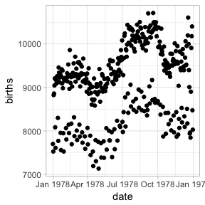

```r
library(mosaicData)
gf_point(births ~ date, data = Births78)
```

Can this interesting pattern be explained by a weekday/weekend effect? We could use color to show the days of the week.

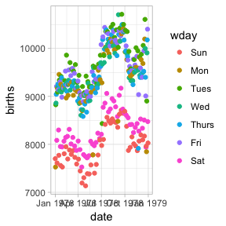

```r
library(mosaicData)
gf_point(births ~ date, color = ~wday, data = Births78)
```

Converting to a line plot highlights the pattern and makes it easier to spot the unusual days.

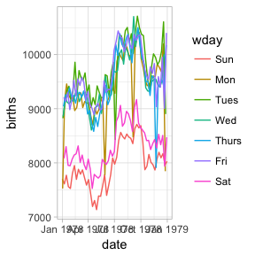

```r
gf_line(births ~ date, color = ~wday, data = Births78)
```

## Plots with more than 2 positional attributes

Some layers require more than two attributes. Typically this happens when the glyphs of a layer are complex objects that could have been made using multiple layers, but belong together conceptually. Examples include

- `gf_pointrange()` – plots a dot flanked by a line segment.
- `gf_linrange()` – like `gf_pointrange()` but without the point.
- `gf_errorbar()` – vertical error bars.
- `gf_errorbarh()` – horizontal error bars.
- `gf_ribbon()` – a band between a line above and line below.

Often these are used to depict some sort of estimate of uncertainty in a measurement or a prediction, but they can be used to represent any data of the correct form. Here we will use `gf_linerange()` and `gf_ribbon()` to indicate the high and low temperatures in New York for the first few months of 2013.

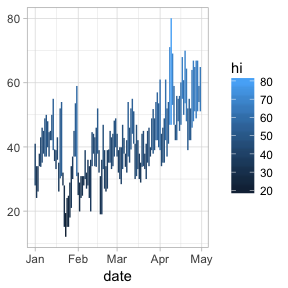

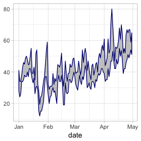

```r
require(weatherData)
Temps <- NewYork2013 %>%
  mutate(date = lubridate::date(Time),
         month = lubridate::month(Time)) %>%
  filter(month <= 4) %>%
  group_by(date) %>%
  summarise(
    hi = max(Temperature, na.rm = TRUE),
    lo = min(Temperature, na.rm = TRUE)
  )
gf_linerange(lo + hi  ~ date, color = ~hi, data = Temps)
gf_ribbon(lo + hi ~ date, data = Temps, color = "navy", alpha = 0.3)
```